# 03. Full Logistic Regression Model

Perry Haaland

11/15/2020

In this document, I’m going to look at fitting a GLM model with all of the terms that have been suggested so far by other team members.

## Load the data

We are all working from a common data set this week.

```r
load("../data/revised_df.RData")
dim(revised_df)
```

```
## [1] 14171     8
```

We recall the variable names.

```r
names(revised_df)
```

```
## [1] "Retained"      "Class"         "Residency"     "DoubleMajor"
## [5] "Enrollment"    "Credits"       "CreditsFailed" "MajorDiv"
```

## Logistic Regression with all terms

In this analysis, I am going to start with the “big” model that has all of the terms and interactions. Unfortunately, the model containing MajorDiv failed to converge (result not shown). The model with the remaining terms is fit below.

```r
fit_all <- glm(Retained ~ (Class +
                                Residency +
                                DoubleMajor +
                                Enrollment +
                                Credits +
                                CreditsFailed)^2,
            data = revised_df,
            family = binomial(link = "logit"))
```

```r
aov_all <- anova(fit_all, test = "LR")
aov_all
```

```
## Analysis of Deviance Table
##
## Model: binomial, link: logit
##
## Response: Retained
##
## Terms added sequentially (first to last)
##
##
##                           Df Deviance Resid. Df Resid. Dev  Pr(>Chi)
## NULL                                      14170     4051.6
## Class                      3    24.21     14167     4027.4 2.255e-05 ***
## Residency                  1    12.74     14166     4014.7 0.0003574 ***
## DoubleMajor                1    35.18     14165     3979.5 3.003e-09 ***
## Enrollment                 1    32.46     14164     3947.0 1.214e-08 ***
## Credits                    1   572.57     14163     3374.5 < 2.2e-16 ***
## CreditsFailed              1     1.02     14162     3373.4 0.3122221
## Class:Residency            3     1.97     14159     3371.5 0.5784454
## Class:DoubleMajor          3     8.84     14156     3362.6 0.0315445 *
## Class:Enrollment           3     9.83     14153     3352.8 0.0200743 *
## Class:Credits              3    30.38     14150     3322.4 1.151e-06 ***
## Class:CreditsFailed        3     0.70     14147     3321.7 0.8723005
## Residency:DoubleMajor      1     0.91     14146     3320.8 0.3398446
## Residency:Enrollment       1     2.57     14145     3318.2 0.1085701
## Residency:Credits          1     1.00     14144     3317.2 0.3170435
## Residency:CreditsFailed    1     0.04     14143     3317.2 0.8377318
## DoubleMajor:Enrollment     1     1.47     14142     3315.7 0.2246890
## DoubleMajor:Credits        1     3.95     14141     3311.8 0.0469444 *
## DoubleMajor:CreditsFailed  1    12.12     14140     3299.6 0.0004976 ***
## Enrollment:Credits         1    19.26     14139     3280.4 1.138e-05 ***
## Enrollment:CreditsFailed   1     0.00     14138     3280.4 0.9835295
## Credits:CreditsFailed      1    64.28     14137     3216.1 1.080e-15 ***
## ---
## Signif. codes:  0 '***' 0.001 '**' 0.01 '*' 0.05 '.' 0.1 ' ' 1
```

## Pareto Plot of Effects

```r
aov_df <- as.data.frame(aov_all)
## fix the last name to make it easier
names(aov_df)[5] <- "Pvalue"
names(aov_df)[4] <- "Resid.Dev"
aov_df$Term = rownames(aov_df)
rownames(aov_df) <- NULL
## first row is the intercept
aov_df <- aov_df[-1,]
## arrange from most to least significant
aov_df <- aov_df %>%
  select(Term, Deviance, Pvalue) %>%
  arrange(Pvalue)
aov_df
```

```
##                         Term     Deviance        Pvalue
## 1                    Credits 5.725657e+02 1.553149e-126
## 2      Credits:CreditsFailed 6.427807e+01  1.080415e-15
## 3                DoubleMajor 3.518213e+01  3.002655e-09
## 4                 Enrollment 3.246405e+01  1.214177e-08
## 5              Class:Credits 3.037541e+01  1.150573e-06
## 6         Enrollment:Credits 1.926402e+01  1.138316e-05
## 7                      Class 2.421243e+01  2.255462e-05
## 8                  Residency 1.274255e+01  3.574310e-04
## 9  DoubleMajor:CreditsFailed 1.212476e+01  4.975676e-04
## 10          Class:Enrollment 9.829295e+00  2.007434e-02
## 11         Class:DoubleMajor 8.836572e+00  3.154455e-02
## 12       DoubleMajor:Credits 3.947380e+00  4.694440e-02
## 13      Residency:Enrollment 2.574913e+00  1.085701e-01
## 14    DoubleMajor:Enrollment 1.474169e+00  2.246890e-01
## 15             CreditsFailed 1.021253e+00  3.122221e-01
## 16         Residency:Credits 1.001104e+00  3.170435e-01
## 17     Residency:DoubleMajor 9.110176e-01  3.398446e-01
## 18           Class:Residency 1.971010e+00  5.784454e-01
## 19   Residency:CreditsFailed 4.194123e-02  8.377318e-01
## 20       Class:CreditsFailed 7.038393e-01  8.723005e-01
## 21  Enrollment:CreditsFailed 4.261820e-04  9.835295e-01
```

Now we make the Pareto Plot.

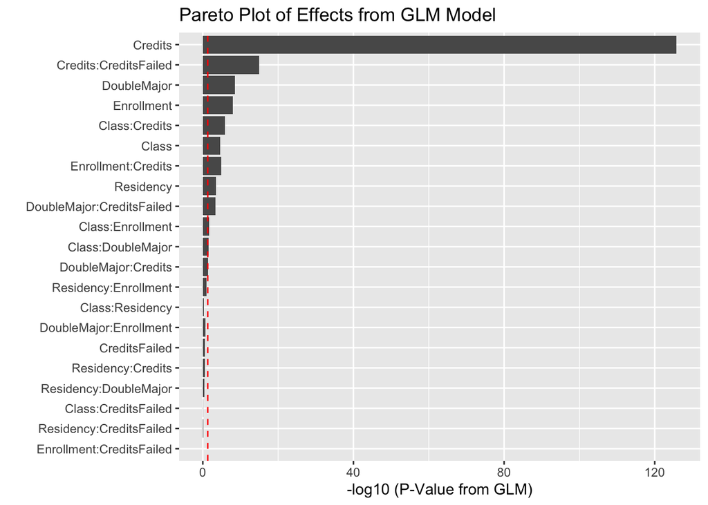

```r
aov_df %>%
  ggplot() +
    geom_col(aes(y = -log10(Pvalue), x = reorder(Term, Deviance))) +
      geom_hline(yintercept = -log10(.05),
                 linetype = "dashed", color = "red") +
    coord_flip() +
  labs(y = "-log10 (P-Value from GLM)",
       x = "",
       title = "Pareto Plot of Effects from GLM Model")
```

- Class = class year: FR, SO, JR, Sr
- Residency = In-state, Out-of-state
- Enrollment = Original enrollment status: New Student or New Transfer Student
- DoubleMajor = Yes = 1, No = 0
- Credits = credit hours earned
- CreditsFailed = credit hours earned - credit hours attempted

The red, vertical dashed line is the significance level of .05.

We note that the different levels of the descriptors Class, Residency, Enrollment, and DoubleMajor have different retention rates. So for example, In-state and Out-of-state residents have different retention rates, in general. The two closely related variables Credits and CreditsFailed seem to capture a dynamic that affects the retention rates overall and also differentially within the different student groups.

The model with MajorDiv did not converge, so we have not shown any results for that. It will need to be investigated separately.

We hypothesize that the two credits variables have an important impact on the student’s perceived progress toward a degree.